# Act report

This report documents all of the EDA efforts done into the project starting by asking questions and using code to answer them in detail followed by Visuals using Python's `matplotlib`, and `seaborn`.

## Analysis and Visualization

The project requires us to provide **at least three (3) insights** and **one (1) visualization**.

```python
# Print the head
df_2 = pd.read_csv('./data/twitter_archive_master.csv')
```

```python
# Get info on the columns
df_2.info()
```

```
<class 'pandas.core.frame.DataFrame'>
RangeIndex: 2073 entries, 0 to 2072
Data columns (total 19 columns):
 #   Column              Non-Null Count  Dtype
---  ------              --------------  -----
 0   tweet_id            2073 non-null   int64
 1   timestamp           2073 non-null   object
 2   text                2073 non-null   object
 3   expanded_urls       2073 non-null   object
 4   rating_numerator    2073 non-null   int64
 5   rating_denominator  2073 non-null   int64
 6   name                2073 non-null   object
 7   jpg_url             2073 non-null   object
 8   img_num             2073 non-null   int64
 9   created_at          2073 non-null   object
 10  full_text           2073 non-null   object
 11  user                2073 non-null   object
 12  retweet_count       2073 non-null   int64
 13  favorite_count      2073 non-null   int64
 14  lang                2073 non-null   object
 15  dog_stage           320 non-null    object
 16  rating              2073 non-null   float64
 17  breed               1531 non-null   object
 18  social_total        2073 non-null   int64
dtypes: float64(1), int64(7), object(11)
memory usage: 307.8+ KB
```

```python
# Get summary statistics
df_2.describe()
```

|  | tweet_id | rating_numerator | rating_denominator | img_num | retweet_count | favorite_count | rating | social_total |
| --- | --- | --- | --- | --- | --- | --- | --- | --- |
| count | 2.073000e+03 | 2073.000000 | 2073.000000 | 2073.000000 | 2073.000000 | 2073.000000 | 2073.000000 | 2073.000000 |
| mean | 7.383634e+17 | 12.265798 | 10.511819 | 1.203570 | 2976.089243 | 8556.718283 | 1.169987 | 11532.807525 |
| std | 6.780118e+16 | 40.699924 | 7.180517 | 0.561856 | 5054.897526 | 12098.640994 | 3.988880 | 16389.509182 |
| min | 6.660209e+17 | 0.000000 | 2.000000 | 1.000000 | 16.000000 | 0.000000 | 0.000000 | 23.000000 |
| 25% | 6.764706e+17 | 10.000000 | 10.000000 | 1.000000 | 634.000000 | 1674.000000 | 1.000000 | 2658.000000 |
| 50% | 7.119681e+17 | 11.000000 | 10.000000 | 1.000000 | 1408.000000 | 3864.000000 | 1.100000 | 5496.000000 |
| 75% | 7.931959e+17 | 12.000000 | 10.000000 | 1.000000 | 3443.000000 | 10937.000000 | 1.200000 | 14292.000000 |
| max | 8.924206e+17 | 1776.000000 | 170.000000 | 4.000000 | 79515.000000 | 132810.000000 | 177.600000 | 210590.000000 |

### **Insight #1: What is the overall distribution of tweet engagement metrics (favorites and retweets)?**

```python
# What is the overall distribution of tweet engagement metrics (favorites and retweets)?
df_2[['favorite_count', 'retweet_count']].describe()
```

|  | favorite_count | retweet_count |
| --- | --- | --- |
| count | 2073.000000 | 2073.000000 |
| mean | 8556.718283 | 2976.089243 |
| std | 12098.640994 | 5054.897526 |
| min | 0.000000 | 16.000000 |
| 25% | 1674.000000 | 634.000000 |
| 50% | 3864.000000 | 1408.000000 |
| 75% | 10937.000000 | 3443.000000 |
| max | 132810.000000 | 79515.000000 |

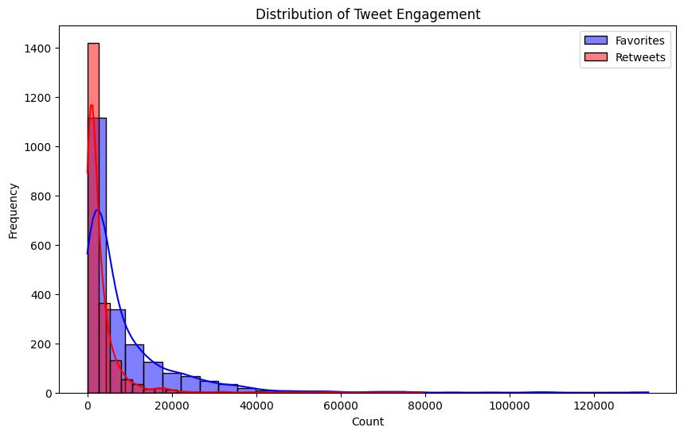

```python
# Adjust the plot size
plt.figure(figsize=(10, 6))

# Create the two plots
sns.histplot(df_2['favorite_count'], bins=30, kde=True, color='blue', label='Favorites')
sns.histplot(df_2['retweet_count'], bins=30, kde=True, color='red', label='Retweets')

# Customize the plot's labels
plt.legend()
plt.title('Distribution of Tweet Engagement')
plt.xlabel('Count')
plt.ylabel('Frequency')

# Show the plot
plt.show()
```

**Conclusion**

- The distribution of both favorites and retweets is heavily right-skewed. This means that most tweets receive a relatively low number of favorites and retweets, while a few tweets receive a very high number of engagements.
- The majority of tweets have fewer than **10,000 favorites and retweets**, with a sharp drop-off as the counts increase.
- There are a few tweets with extremely high engagement **(up to around 120,000 favorites)**, indicating viral tweets that gain exceptional attention.

### **Insight #2: How are the different dog stages (dog_stage) represented in the dataset?**

```python
# Count the occurrences of each dog stage
dog_stage_counts = df_2['dog_stage'].value_counts()
```

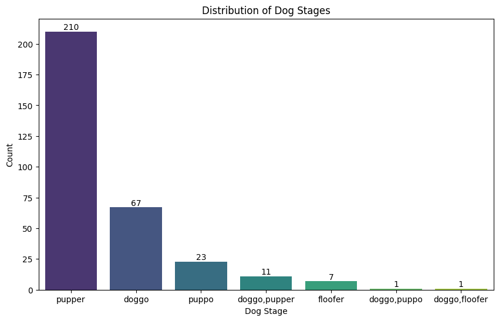

```python
# Create the plot
plt.figure(figsize=(10, 6))
sns.barplot(x=dog_stage_counts.index, y=dog_stage_counts.values, hue=dog_stage_counts.index, palette="viridis")

# Customize the plot's labels
plt.title('Distribution of Dog Stages')
plt.xlabel('Dog Stage')
plt.ylabel('Count')

# Add labels with numbers
for i, count in enumerate(dog_stage_counts.values):
    plt.text(i, count, str(count), ha='center', va='bottom')

# Show the plot
plt.show()
```

### **Insight #3: What are the most frequently mentioned dog breeds and how do they correlate with tweet engagement?**

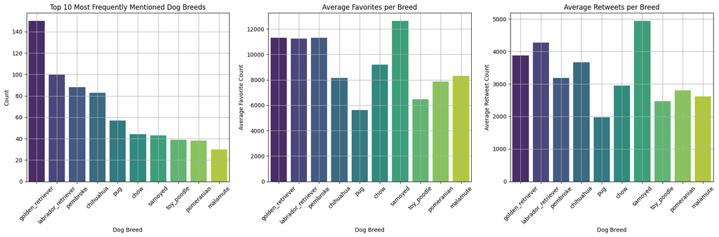

```python
# Filter out rows with missing breed information
df_breeds = df_2.dropna(subset=['breed'])

# Count the occurrences of each breed
breed_counts = df_breeds['breed'].value_counts().head(10)  # Get the top 10 most frequently mentioned breeds

# Calculate average engagement for each breed
average_engagement = df_breeds.groupby('breed')[['favorite_count', 'retweet_count']].mean().loc[breed_counts.index]

# Create a figure with subplots
fig, axs = plt.subplots(1, 3, figsize=(18, 6))  # 1 row, 3 columns

# Plot the most frequently mentioned breeds
sns.barplot(x=breed_counts.index, y=breed_counts.values, palette="viridis", hue=breed_counts.index, dodge=False, ax=axs[0])
axs[0].set_title('Top 10 Most Frequently Mentioned Dog Breeds')
axs[0].set_xlabel('Dog Breed')
axs[0].set_ylabel('Count')
axs[0].tick_params(axis='x', rotation=45)
axs[0].legend([], [], frameon=False)
axs[0].grid(True)

# Plot the average favorites per breed
sns.barplot(x=average_engagement.index, y=average_engagement['favorite_count'], palette="viridis", hue=average_engagement.index, dodge=False, ax=axs[1])
axs[1].set_title('Average Favorites per Breed')
axs[1].set_xlabel('Dog Breed')
axs[1].set_ylabel('Average Favorite Count')
axs[1].tick_params(axis='x', rotation=45)
axs[1].legend([], [], frameon=False)
axs[1].grid(True)

# Plot the average retweets per breed
sns.barplot(x=average_engagement.index, y=average_engagement['retweet_count'], palette="viridis", hue=average_engagement.index, dodge=False, ax=axs[2])
axs[2].set_title('Average Retweets per Breed')
axs[2].set_xlabel('Dog Breed')
axs[2].set_ylabel('Average Retweet Count')
axs[2].tick_params(axis='x', rotation=45)
axs[2].legend([], [], frameon=False)
axs[2].grid(True)

plt.tight_layout()
plt.show()
```

**Conclusion**

- We can identify surprising breeds that are more popular online than traditionally expected.
- We can potentially discover a correlation between a breed's mention frequency and its favorability or retweet rate.
- The plots may expose outliers, breeds with high mentions but low engagement, or vice versa.

### **Insight #4: Has WeRateDogs' popularity (social feedback) changed over time?**

```python
# Group by date and calculate the mean of favorite_count and retweet_count columns.
popularity_over_time = df_2.groupby('timestamp')[['favorite_count', 'retweet_count']].mean()

# Test case
popularity_over_time.head()
```

| timestamp | favorite_count | retweet_count |
| --- | --- | --- |
| 2015-11-15 22:32:08+00:00 | 2535.0 | 532.0 |
| 2015-11-15 23:05:30+00:00 | 132.0 | 48.0 |
| 2015-11-15 23:21:54+00:00 | 128.0 | 47.0 |
| 2015-11-16 00:04:52+00:00 | 311.0 | 147.0 |
| 2015-11-16 00:24:50+00:00 | 111.0 | 41.0 |

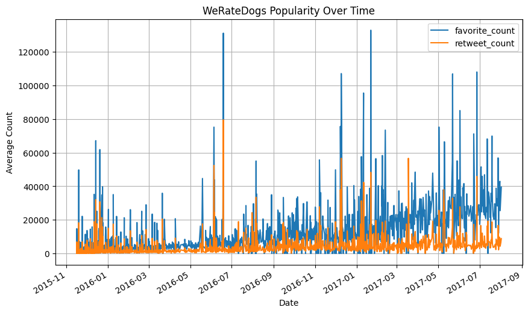

```python
# Plot the data
popularity_over_time.plot(figsize=(10, 6))
plt.xlabel('Date')
plt.ylabel('Average Count')
plt.title('WeRateDogs Popularity Over Time')
plt.grid(True)
plt.show()
```

**Conclusion**